# Yelp Data Analysis

### Location and Review Counts

#### Importance of Location in Businesses

In the last part, we see there are many successful franchises in terms of their size and populairty. We may think about what are the factor demonstrate their success in businesses. Location is important because that factors greatly into how your initial customers can find you, and how often your existing customers visit. And the qustion now becomes, **is there a correlation between location and reputation of a business?** In this case, I will use revire counts to measure a business's reputation.

#### Procedure

The procedure I will use to answer this question is as following.

1. Use map to visualize the location of businesses with their review counts, to see if there any obvious pattern.
2. Group the data in terms of their location, compare their review counts in multiple ways.

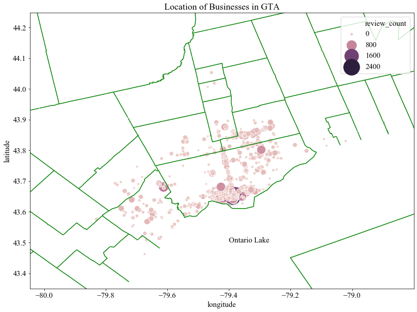

From the map, we see many businesses are concentrated around city of Toronto. For businesses outside the city, we find they spread widely. For review counts attribute, just based the map, we can not tell if there is a strong difference between businesses in different regions. Therefore, I will use other tools to see if there is any relationship between location and review counts ofbusinesses. I will group the data into two parts, one is businesses inside the city of Toronto, the other only contains businesses outside the city of Toronto, and make comparison between them.

From the map, we may also see businesses with review counts more than 2400 are only inside the City. So, let's consider about extreme cases where review_counts is higher than 100, to see how many of these businesses are located inside the cIty.

[figure not shown]

From the piechart, we see that though the number of businesses inside the City of Toronto is just slightly higher than outside the city. However, about 75% of businesses with review counts higher than 100 are contributed by businesses inside the city. This is resaonable, because city of Toronto has a more condensed populuation and is treated like a central business distinct. Therefore, more popular businesses with high review counts may choose to locate around this region.

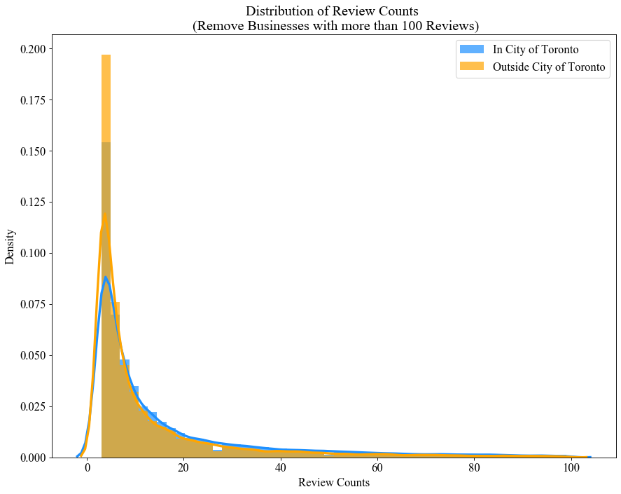

Now, let's remove those businesses with review counts higher than 100, and plot the distribution for businesses with lower review counts. We find that both inside and outside of City follow a similar distribution. Most businesses have reviews less than 20. We see outside city of Toronto has a larger number of businesses with extreme low reviews.

### Example: Locations of Tim Hortons and Starbucks in GTA

#### The competition between Tim Hortons and Starbucks from location perspective

Recall the previous part, we find Tim Hortons and Starbucks are two most common franchises in GTA. And in the last part, we also demonstrates the importance of location in businesses. Now, let's combine these findings together, we may ask, What is the strategy for starbucks and tim hortons choose the locations of their businesses? How does this related to their competition?

#### Procedure

1. I will plot the distribution of two businesses on a map.
2. I will do further investigation on for every Tim Hortons, find the shortest distance between it and a Starbucks.

Then for every Tim Hortons, let's find a shortest starbucks nearby.

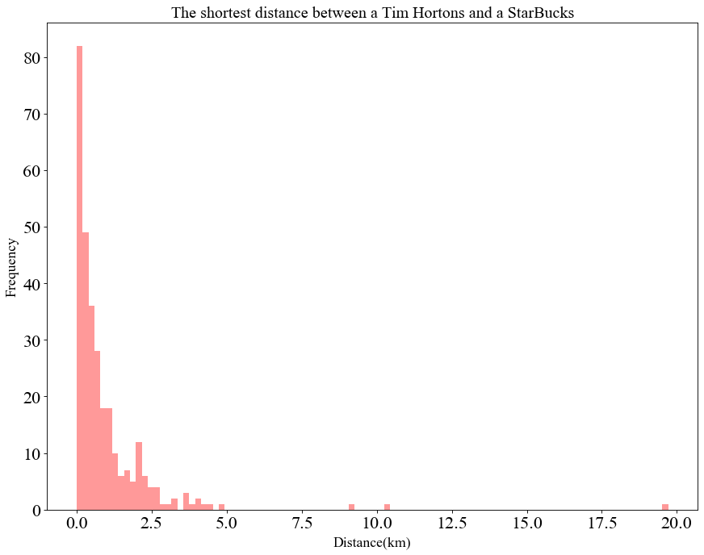

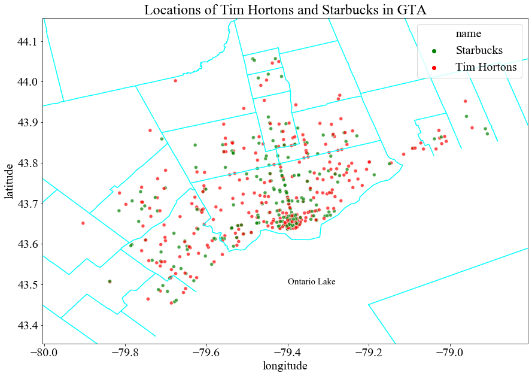

From the map, we see green dots(Starbucks) and red dots(Tim Horton's) are concentrated together especially inside the city. Although as we moved away from the city, though the dense of their businesses is not as high as inside the city, we could still find that for most red dots, there is a green dot that locates very close to it. ThIs is reasonable, when one franchise set up its branch on a certain location, the selected location must be the result of careful calculation of traffic flow and careful investigation of the target market, so this outlet is the most Excellent solution. However, this location will also be a good choice for its competitor since they sell the similar products with similar targeted market.

## View the Businesses at User's Perspective

Again, Yelp is a tool to shorten **the information gap** between two sides of transaction, on the one side, are the **businesses** on the other side, are the **customers**. In the previous part, we dicusses about businesses in depth. In this part, we will use our findings in the previous part to invesitigate more characteristics of users and reviews in the dataset. I will first load this huge dataset.

```
Finish Loading Review dataset
```

```
Finish Loading User dataset
```

### A small group of users that is responsible for most reviews

In the previous part, we see there are some businesses contribute more to the market, while some are not so significant. Similarly, a small group of users may contribute most reviews. In this part, i will invesitigate if there is a small group of users that is responsible for most reviews. In most cases, the more reviews a user wrote, the more reliable is the user. If there is a group responsible for most reviews, we can help the Yelp **develop an algorithm** to filter meaningful and reliable reviews.

#### Attributes of a User

Since we want to form a group users with high **review_counts**, the characteristics of this group must be defined by other attributes in the user dataset. By overview of the data, we see **elite**, **fans**, **compliment_total** may relate to the review counts by their definition. By definition, a user may become an elite if he/she provides thoughtful reviews, awesome photos, sending compliments, up-voting reviews. I look deeper into the relationship between these attributes and review counts.

#### Procedure

1. Group users into elite users and other users. Find the total reviews they contribute to the dataset in each group.
2. Group users into users who have more than 3 fans and users who have less than 3 fans (inclusive). Find the total reviews they contribute to the dataset in each group.
3. Find the overlap between two groups.

[figure not shown]

From the pie chart, we see that only 4 percent of users are elite. Howevr, they contribute more than 40% of comments. Therefore, elite users is a small group that contributes to many reviews in this dataset. This is reasonable, as we discusses above, users can become elite only if they provide high quaility reviews with many other users' complementary reflections. So an elite user should have written many reviews.

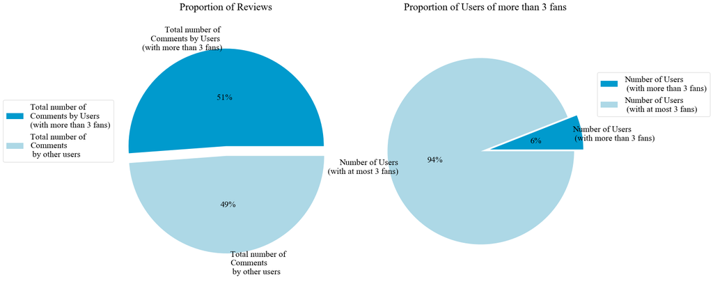

From the pie chart, we see although there are only 6% of users have more than 3 fans, but they contribute to more than half of the reviews in the dataset. Therefore, we may conclude this is also a small group of users contribute to most reviews in the dataset. This is also reasonable, the most common way for users to attract other users in Yelp is through writing reviews, for users who wrote reviews more frequent than other users, they should have more fans.

So, the next question comes to are users with more fans actually overlap with elite users. In another word, are elite users and users with more than 3 fans actually the same group of people.

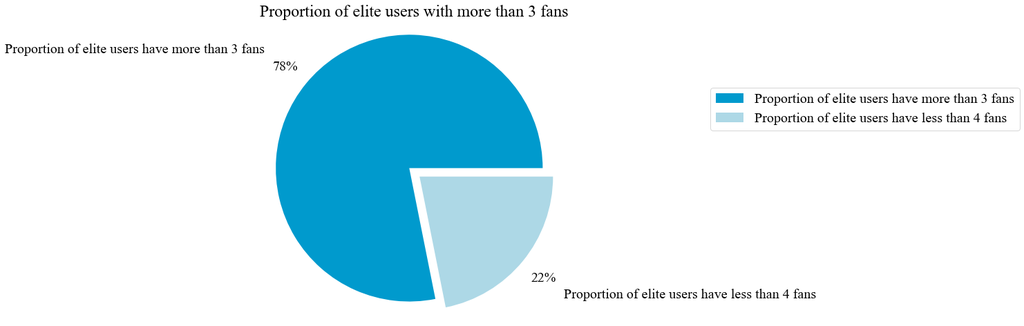

From the pie chart, we see that about 80% of elite users have more than 3 fans.

### View the competition in User's perspective

#### A Competition Between Tim Horton's and Starbucks

Recall previous part, we know Tim Horton's and Starbucks are two most common franchises in GTA in terms of their number of branch businesses, **quantity**. Since Tim Horton's and Starbucks provide similar services and products, they are the major **competitors** in this region. However, we know the quantity is just one perspective of businesses, the **quality** of service and product is also essential for the development of businesses. I will dig deeper into their competition in terms of their service quality in this part. And then give two companies some suggestions for their future development.

#### Reviews in the Dataset

Which one is better in Toronto citiezen's view? for How do people actually think of them? These are controversial questions. To know about the quality of their services and products, we need to start with their customers. The Yelp dataset provides us with a large number of customers' reviews. We can not read through each review one by one since there about thousands of them. However, there are still two ways for us to interpret these reviews in an effcient way.

1. **The (adjective）keywords in reviews.**
2. **The sentiment scores in reviews.**

#### The Procedure

Based on above, the procedure I use to answer this question is

1. **Group the data**. Select the dataframe of reviews about GTA's Tim Horton's and Starbucks.
2. **Compare keywords**. Extract the keyword in grouped reviews, compare and contrast them.
3. **Compare sentiment scores**. Extract the sentiment scores in grouped reviews, compare and contrast them.
4. **Compare reviews of common users**. Find characteristcs of reviews written by users who reviewed both establishments.

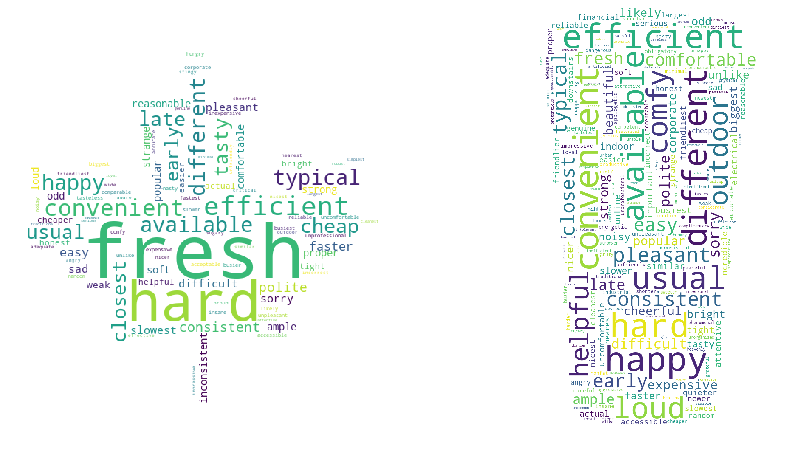

The left maple leaf word cloud corresponds to keywords appear in reviews for Tim Horton's. The right coffee cup word cloud corresponds to keywords appear in reviews for Starbucks. The size of the words corresponds to the frequency of the words appeared in the review. Obvisouly, we see a positive words "efficient", "fresh", "convenient" occur in both wordclouds, this demonstrates the common characteristics of two franchises in user's view. On the other hand, we find some negative words, such as 'hard', 'load', 'late' appear in both word clouds. The similariy of keywords is high between two wordclouds. This is reasonable, because both businesses provide similar services.

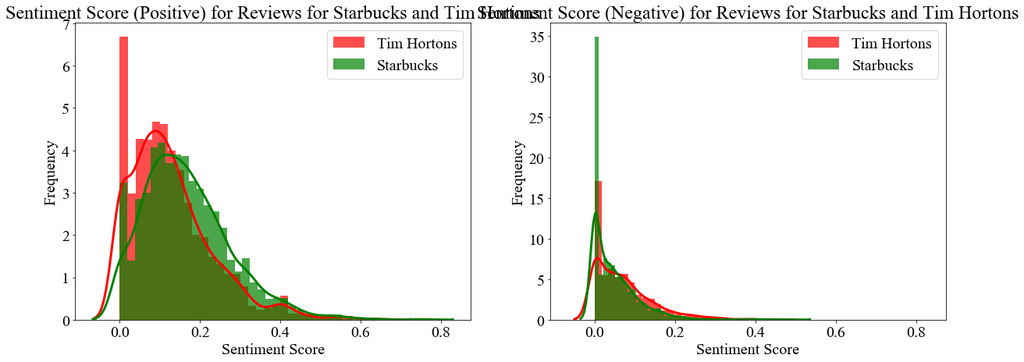

From the two distribution plots above, we find that the frequency of positive reviews for Tim Horton is much lower than Starbucks. The peak of positive sentiment score for Tim Hortons is zero. For high positive sentiment score, Starbucks always has a higher frequency than Tim Hortons. On the other hand, in the negative sentiment score distribution, the peak of Starbucks is 0. This indicates that Starbucks always left costumers with a more positive impression. For high negative sentiment score, Starbucks always has a lower frequency than Tim Hortons.

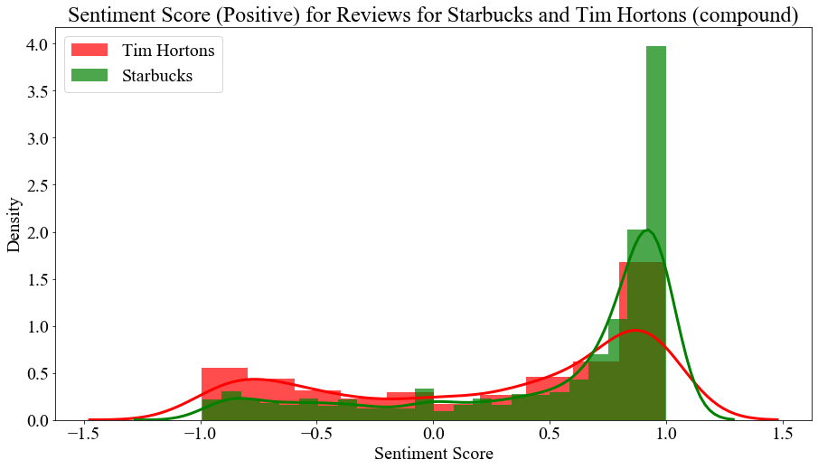

Now, lets's look at the compund distribution. We see most Starbucks reviews are generally more positive than Tim Hortons. We can combine this with the result of average star evluation for two businesses in GTA. For Starbucks, it has a higher average stars (3.4 stars) than Tim Hortons (2.6 stars). Both star evulation and review emotion demonstrate Starbucks has a better impression for customers than Tim Hortons.

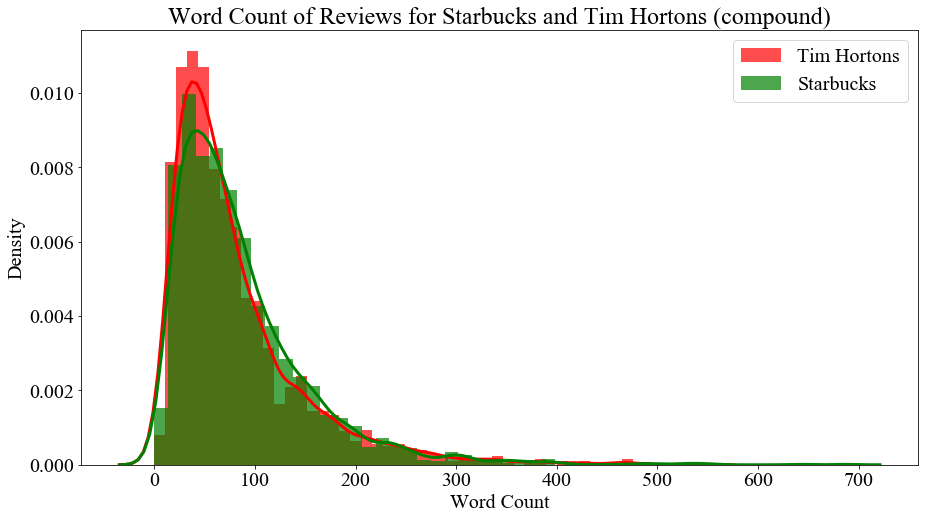

Another aspect to look at is word count of reviews for two businesses. We find that they follow similar distribution. There is not a huge difference between review lengths for two businesses.

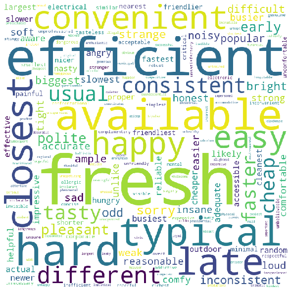

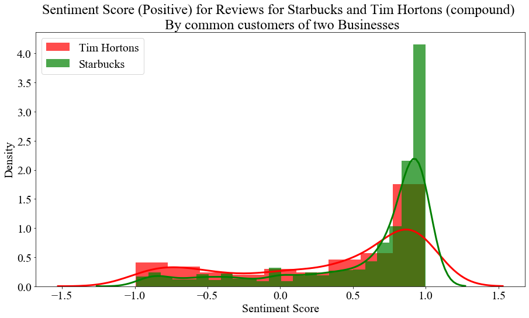

We see for users who have been to both Tim Hortons and Starbucks, the sentiment score of Starbucks is still generally higher than Tim Hortons. So it is fair to judge Starbucks provide better service and products in users' views.

### A Conclusion for this competition

Combining the results of previous part. We may conclude that the competition between Starbucks and Tim Hortons is fierce. They always locate around each other in GTA. Though Starbucks falls behind int terms of its business quantity (the number of branch businesses), it has a better impression than Tim Hortons in customer's view. Therefore, Tim Hortons may need to improve its service quality to keep its leading position in terms of business quantity.

### Paid Reviewers

I break this part into several parts.

#### How do fake reviews affect us?

As [Yelp](https://www.yelp-support.com/article/Can-I-report-a-business-that-is-trying-to-pay-people-to-write-positive-reviews?l=en_US) company mentioned in their website, paid reviews are not allowed. However, according to [Fortune](https://fortune.com/2013/09/26/yelps-fake-review-problem/), this problem currently still exists, and may have bad effects on several aspects.

1. **Damage the reputation of the Yelp evaluation system.** Yelp is a review-based company, without reliability of reviews, it will definitely lose its attractions to customers.
2. **Mislead Users**. According to Yelp’s VP of corporate communications Vince Sollitto, fake reviews will "mislead consumers, it violates our guidelines, but more importantly it violates the law.”
3. **Damage the fairness of the market.** If a single businesses gain more profit through buying fake reviews, more companies will pay attention to instead of providing products and services itself. This may lead to a vicious competition in the market. Yelp, as a Influential company, should be responsible for its inflence on the market, lead the market in a healthy way.

#### Limitation and Ideal Approach

There are two aspects we can look at when we detect paid reviews, they are characteristics of **reviews** themseleves and then combine it with characteristics of **users**. Unfortunately, we do not have a truthfulness of review in the given dataset. I try to look for sample fake review dataset online, but they are neither for yelp nor for other businesses reviews. This is the biggest **limitation** for this question. If I have a sample of large number fake reviews, I will construct a decision tree. This **decision tree** will that takes the review text, some other characteristics of reviews and user information as the input, and whether a given review is fake. Also, by detecting reviews of a given user, we can also predict whether a user is a paid writer.

#### What do Fake Reviews may look like?

Even if we do not have examples of fake reviews, we can still predict characteristics of fake reviews based on our life experience and results of other studies.

1. **Automatic-Generated Fake Reviews**. These reviews are low quality, but the 'writer' of this review may write these reviews very frequently. So, below is a predicted standard for Automatic-Generated Fake Reviews.
   1. Review text has length lower than 20 words. (Review Aspect)
   2. The review is not useful, funny and cool (these attributes are all zero). (Review Aspect)
   3. The writer of these reviews does noy have fans or any compliments. (User Aspect)
   4. The user only gives 5 stars evaluation, and the number of reviews he/she wrote should be more than 10. (User Aspect)
   5. It would be better if we have **IP addresses** of these reviewers, since a user may use different accounts with the same IP address.
2. **Hand-Written Fake Reviews** These reviews have higher quality, and the 'writer' of these reviews may write these reviews similarly as normal users. This makes this kind of fake reviews harder to distinguish, so that we have to look into the contents of reviews. Below is a predicted standard for Hand-Written Fake Reviews.
   1. Review text has length between 10-50 words. (Review Aspect)
   2. The review may be marked as at most one useful, funny and cool. (Review Aspect)
   3. A lot of superlatives and not much description. Phrases like “a must-read” and “life-changing” are giveaways. References to other people such as “my family” or “my husband. (Review Aspect)
   4. Reviews that sound like a marketing brochure from the company or use the full official name of the product. (Review Aspect)
   5. The user only gives 5 stars evaluation, and the number of reviews he/she wrote should be more than 20. (User Aspect)
   6. The sentiment of language in reviews is overall too positive. (User Aspect)
   7. Self-Contradiction. For example, a reviewer may have a 'husband' in one review, while have a 'wife' in another review. (User Aspect)

Notice that the second kind of fake reviews may require some advanced tool including Lexical features such as word n-grams, part-of-speech n-grams, and other lexical attributes, semantic inconsistency checking. I will not cover investigation of Hand-Written Fake Reviews in this part, and this can be improved in the future.

#### Result

- "yeah buddy' dam good' wish i had some right now" -- User ID: jmO2OUxTaIV_rLRjRXSxuA
- "This is a blast from the past! Good quality food and service. Local owners, local employees great value" (Repeted Reviews) -- User ID: hU62m1mokKTcEm4aNrxOiQ
- "Wow, just wow I can't tell you how good this place is, while in Montreal this is a must." -- User ID: Zduokg2jobtiohiOpND6nw

## Conclusion

In this report, we go through the **Yelp business dataset in an overall perspective** (Part I), and then we zoom into **businesses in GTA** (Part II), and finally look at the businesses from **users' aspect** (Part III).

In the first part, we find that most businesses's **locations** in this dataset are concentrated in some regions in the United States and Canada. And through the investigation on the **category** attribute, we find restaurant and its subcategories are the most frequent businesses in the dataset. Also, we recommend to use the **hierarchical organization** to record category information in the future. Next, we discuss the convenience of establishments in terms of their bike parking availability. We find that some categories may have a higher proportion of businesses with bike parking available because of **the cultural background**. And we also find bike parking availability may have a positive **assoication** with the evaluation of the businesses. In fact, more yelp reviews may also lead to a higher rating for a business (except 5 star evalution).

In the last part, we focus on user's opinion on businesses. We find that there is a group of users contribute to most reviews in the dataset. Some evidence show that many of them are elite users of Yelp. Then, we continue talking about the **competition** between Tim Hortons and Starbucks in terms of the quality of their product and service. We find that though Tim Hortons kept the lead of the **quantity** of businesses, it fell behind in the **quality** of businesses. Lastly, we do a further investigation on **detection of 'paid review'**. Due to the limitation of the dataset, we cannot form an accurate procedure to detect the truthfulness of the review.

Again, throughout the whole report, we have better understandings of following aspects:

1. Characteristics of all Businesses in the dataset, Including their popularity, location, etc.
2. Characteristics of Businesses in the dataset in a particular region, compare it with the whole data set. Since we are in Toronto, so we will do investigation on the GTA.
3. Characteristics of reviews in the dataset, and make connection with users and reviews.

The result of this report may also help:

1. Improvement of Yelp service.
2. Development of Local Businesses.
3. Prediction of future businesses trend.

## Limitation

There are some limitations of this report that may be improved in the future.

1. Yelp data set may not represent the true businesses condition. Not everyone uses Yelp to evaluate local businesses, this data set may only reflect a proportion of people's opinion on businesses. So when we do analysis and want to conclude public opinion's on a business, we need to pay attention to this limitation.
2. This data set is a subset. Based on our finding in part I, we know this data set only contains businesses in a small proportion in cities. Therefore, we cannot conclude anything about businesses 'in the United States' or even larger scale. Instead, we can only conclude what is inside the data set.
3. Reliability of business reviews. Everything we did in the part 3 is based on the reviews in the dataset. However, as we know, the reviews have problems with their reliability due to fake review issue.
4. Category analysis. The analysis of category is not well-planned, since the design of this attribute has some weakness as we discussed above. This may leads to inaccurate and meaningless result when do investigation on this part. (If two categories have a huge overlap with each other, we may over count the number of businesses in those categories).
5. The accuracy of data (location). At the begining, we find that some data have obvious mistakes. The data set may still contain hidden mistakes. Also, I did not make use of postal code when filter data for businesses in GTA, this may leads to inaccurate conclusion in the end.

## Future Steps

In the future, we can improve our study in the following ways.

1. When we have have enough sample (of reviews) with labels, in another word, the truthfulness of each review is recorded, we can implement supervised label classification to improve our detetction of fake reviews.
2. We can improve our investigation on category, and help Yelp to construct a hierarchical organization of business category system.
3. We still did not cover many attributes in the datasets, since they look unrelated to the topic of this report. However, there may be more interesting information behind those attributes, in the future, we may start with attributes we did not cover this time, and implement further investigation.
4. As we discusses in the limatation. This dataset may not represent the true situation of local businesses. So we can make use of other evaluation system such as Google Review, using multiple datasets helps us to conclude a more comprehensive result.